# R 語言的五十道練習

> 簡介

[數據交點](https://www.datainpoint.com) | 郭耀仁 yaojenkuo@datainpoint.com

## 什麼是 R 語言

## （沒什麼用的）冷知識

- R 語言的命名由來：為什麼命名為 R？
- 因為 R 語言的前身是一個被稱為 S 語言的統計程式語言（A language for **S**tatistics）。

## R 在英文字母的排序在 S 前一個

```python
A2Z
```

```
'ABCDEFGHIJKLMNOPQRSTUVWXYZ'
```

## 程式語言的分類

- 廣泛用途（General-purposed）程式語言。
- 專門用途（Special-purposed）程式語言。

## 從 IEEE Top Programming Languages 2020 暸解程式語言分類

[figure not shown]

來源：https://spectrum.ieee.org/static/interactive-the-top-programming-languages-2020

## R 語言是一個專門用途的程式語言

- 由紐西蘭奧克蘭大學的 Ross Ihaka 和 Robert Gentleman 所開發設計。
  - 另有一說 R 語言的命名由來是取自兩位作者的名字。
- 目前由 [R 開發核心團隊](https://www.r-project.org/)開發維護。
- 專注在資料科學應用領域的「統計程式語言」。

## R 語言與其他廣泛用途的程式語言相對比較

- 向量化運算是內建的功能。
- 以「函數」（Functions）作為主體。
- 使用者不需要學習類別（Class），因此學習路線比較短。

## R 語言與其他資料科學的專門用途程式語言相對比較

- 授權種類的不同：Matlab、SAS 屬於商業授權，R 語言則是屬於開源授權。
- 使用者數量的不同：Julia 是相對年輕的程式語言，相較之下 R 語言的開發者更多、使用者社群更龐大。

來源：https://spectrum.ieee.org/static/interactive-the-top-programming-languages-2020

## 為什麼 R 語言是重要的

## 2020 Kaggle ML&DS Survey 中 R 語言在資料科學家日常頻繁使用語言中排名第三。

來源：https://www.kaggle.com/c/kaggle-survey-2020

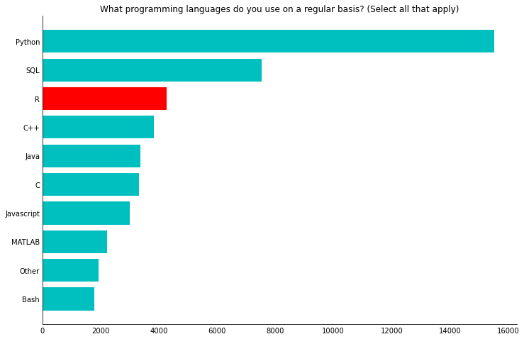

```python
plot_kaggle()
```

## R 語言在資料科學專門用途程式語言中社群討論度最高

[figure not shown]

來源：https://insights.stackoverflow.com/trends

## Google 的資料分析師證照將 R 語言列入為必修程式語言。

[figure not shown]

來源：https://www.coursera.org/professional-certificates/google-data-analytics

## 重點統整

- R 語言的前身是一個被稱為 S 語言的統計程式語言。
- R 語言是一個專注在資料科學應用的專門用途程式語言。
- R 語言由紐西蘭奧克蘭大學的 Ross Ihaka 和 Robert Gentleman 所開發設計。

## 重點統整（續）

- 為什麼 R 語言是重要的？
  - R 語言在資料科學家日常頻繁使用語言中排名第三。
  - R 語言在資料科學專門用途程式語言中社群討論度最高。
  - R 語言被 Google 的資料分析師證照列入為必修程式語言。